# SNCF Trains analysis

```r
options(warn=-1)
library(readxl)
#df_raw = read.csv("full_trains.csv")
df_raw = read_xlsx(path="regularite-mensuelle-tgv-aqst_upd.xlsx")
library(igraph)
library(ggraph)
library(tidyverse)
library(scales)
library(patchwork)
library(dplyr)
library(viridis)
library(hrbrthemes)
```

Select everything except comments for cancellation, departure and arrival delays

```r
df = df_raw %>%
  select(-c(comment_cancellations,comment_delays_at_departure,comment_delays_on_arrival))

df = df %>%
  mutate(pct_late_departure = num_late_at_departure/total_num_trips,
         mean_monthly_pct_cancelled = num_of_cancelled_trains/total_num_trips)
```

Check for missing values

```r
na_count = data.frame(na_sum = colSums(is.na(df)))%>%
arrange(desc(na_sum))

na_count %>%
filter(na_sum !=0)
```

|  | na_sum |
| --- | --- |
| pct_late_departure | 73 |
| mean_monthly_pct_cancelled | 10 |

```r
head(df)
```

| year | month | service | departure_station | arrival_station | journey_time_avg | total_num_trips | num_of_cancelled_trains | num_late_at_departure | avg_delay_late_at_departure | avg_delay_all_departing | num_arriving_late | avg_delay_late_on_arrival | avg_delay_all_arriving | num_greater_15_min_late | avg_delay_late_greater_15_min | num_greater_30_min_late | num_greater_60_min_late | delay_cause_external_cause | delay_cause_rail_infrastructure | delay_cause_traffic_management | delay_cause_rolling_stock | delay_cause_station_management | delay_cause_travelers | pct_late_departure | mean_monthly_pct_cancelled |
| --- | --- | --- | --- | --- | --- | --- | --- | --- | --- | --- | --- | --- | --- | --- | --- | --- | --- | --- | --- | --- | --- | --- | --- | --- | --- |
| 2018 | 1 | National | BORDEAUX ST JEAN | PARIS MONTPARNASSE | 141 | 870 | 5 | 289 | 11.247809 | 3.6931792 | 147 | 28.43673 | 6.511118 | 110 | 6.511118 | 44 | 8 | 36.13445 | 31.09244 | 10.924370 | 15.966387 | 5.042017 | 0.8403361 | 0.33218391 | 0.005747126 |
| 2018 | 1 | National | LA ROCHELLE VILLE | PARIS MONTPARNASSE | 165 | 222 | 0 | 8 | 2.875000 | 0.0957958 | 34 | 21.52402 | 5.696096 | 22 | 5.696096 | 5 | 0 | 15.38462 | 30.76923 | 38.461538 | 11.538462 | 3.846154 | 0.0000000 | 0.03603604 | 0.000000000 |
| 2018 | 1 | National | PARIS MONTPARNASSE | QUIMPER | 220 | 248 | 1 | 37 | 9.501351 | 1.0039811 | 26 | 55.69231 | 7.578947 | 26 | 7.548387 | 17 | 7 | 26.92308 | 38.46154 | 15.384615 | 19.230769 | 0.000000 | 0.0000000 | 0.14919355 | 0.004032258 |
| 2018 | 1 | National | PARIS MONTPARNASSE | ST MALO | 156 | 102 | 0 | 12 | 19.912500 | 1.9666667 | 13 | 48.62308 | 6.790686 | 8 | 6.724757 | 6 | 4 | 23.07692 | 46.15385 | 7.692308 | 15.384615 | 7.692308 | 0.0000000 | 0.11764706 | 0.000000000 |
| 2018 | 1 | National | PARIS MONTPARNASSE | ST PIERRE DES CORPS | 61 | 391 | 2 | 61 | 7.796995 | 0.8868895 | 71 | 12.40516 | 3.346487 | 17 | 3.346487 | 6 | 0 | 21.21212 | 42.42424 | 9.090909 | 21.212121 | 6.060606 | 0.0000000 | 0.15601023 | 0.005115090 |
| 2018 | 1 | National | QUIMPER | PARIS MONTPARNASSE | 223 | 256 | 1 | 9 | 16.333333 | 0.5794771 | 21 | 39.09524 | 5.940850 | 21 | 5.917643 | 9 | 2 | 27.77778 | 55.55556 | 0.000000 | 5.555556 | 5.555556 | 5.5555556 | 0.03515625 | 0.003906250 |

Now, let’s look a boxplot of % late departures per year

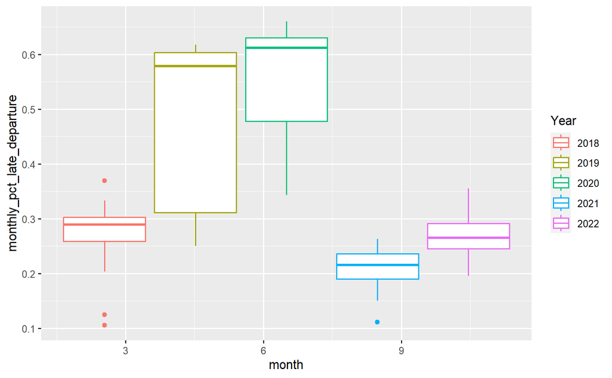

```r
df %>%
  mutate(pct_late_departure = num_late_at_departure/total_num_trips) %>%
  group_by(year,month) %>%
  summarise(monthly_pct_late_departure = mean(pct_late_departure, na.rm = TRUE)) %>%
  ggplot(aes(month,monthly_pct_late_departure,color = factor(year)))+
    geom_boxplot(size = 0.5)+
    labs(color = "Year")
```

2019 and 2020 medians are around 60%.

Create a bar chart by month for all years.

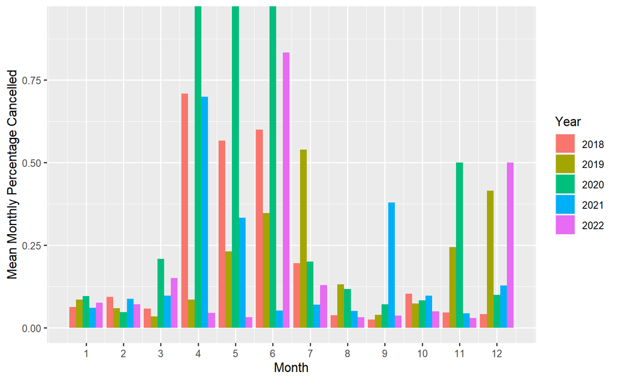

```r
df %>%
  ggplot(aes(x = month, y = mean_monthly_pct_cancelled, fill = factor(year))) +
  geom_col(position = "dodge", na.rm = TRUE) +
  labs(x = "Month", y = "Mean Monthly Percentage Cancelled", fill = "Year") +
  scale_x_continuous(breaks = 1:12)
```

We can see high cancellation rates in the months of April, May and June on 2020 because of the lockdown for the pandemic.

We can also see high cancellation rates: - For 2018 in the months of April, May and June - In July and December for 2019 - In June and December 2022 These high cancellation rates are due to striking by SNCF employees against government plans to change the pension age.

Check the service variable.

```r
df %>%
group_by(year,service) %>%
count()+
 geom_col(position = "stack", na.rm = TRUE)
```

[output not shown]

We can use the ggraph package to plot the stations network.

```
Using "stress" as default layout
```

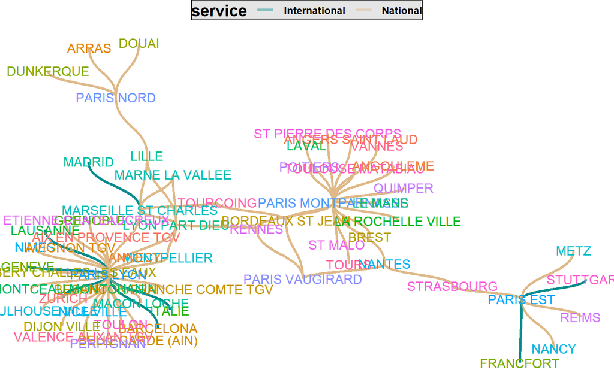

```r
p1 =  df %>%
  group_by(departure_station,arrival_station,service) %>%
  mutate(id = map2_chr(departure_station, arrival_station,
                       ~str_flatten(sort(c(.x,.y)))))%>%     # For each unique pairs of stations create an id
  group_by(id) %>%
  rename(from = departure_station,to = arrival_station)


p1 = p1[,c("from","to","service","id")]
graph1 = graph.data.frame(p1)



   ggraph(graph1) +
    geom_node_text(aes(label = name,color = name))+
  geom_edge_diagonal(aes(color = service),alpha = 0.4,width = 1)+
  scale_edge_color_manual(values=c("darkcyan","burlywood"))+
  geom_node_text(aes(label = name,color = name))+
    theme_void()+

    scale_colour_discrete(name  ="service",
                            breaks=c("National", "International"),
                            labels=c("National", "International"))+
    theme(legend.position="top",
          legend.background = element_rect(fill="gray90"),
        legend.text =element_text(face="bold"),
        legend.title = element_text(size=14,face="bold"))
```

Plot the mean monthly % of late departures for each year

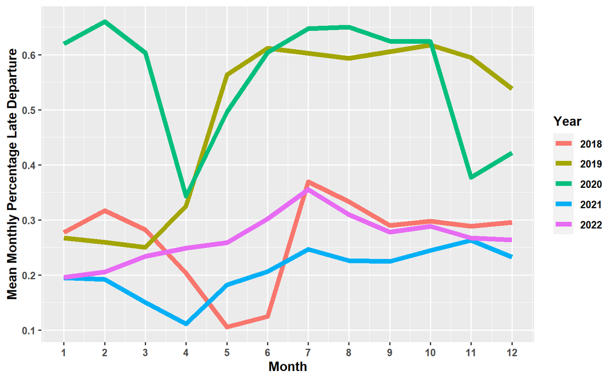

```r
df %>%
  mutate(pct_late_departure = num_late_at_departure/total_num_trips) %>%
  group_by(year, month) %>%
  summarise(monthly_pct_late_departure = mean(pct_late_departure, na.rm = TRUE)) %>%
  ggplot(aes(month, monthly_pct_late_departure, color = factor(year))) +
  geom_line(size = 2) +
  scale_x_continuous(breaks = 1:12) +
  labs(x = "Month", y = "Mean Monthly Percentage Late Departure", color = "Year") +
  theme(axis.text = element_text(face = "bold"),
        axis.title = element_text(face = "bold"),
        legend.text = element_text(face = "bold"),
        legend.title = element_text(face = "bold"))
```

2019 and 2020 are showing excessively high percentage of late departures, around 60% on average for both years. The pandemic could be a reason for the high percentage in 2020. In 2019 the % of late departures increased dramatically after April, this could again be due to staff striking.

But that’s quite a messy graph because we need to recode our year variable

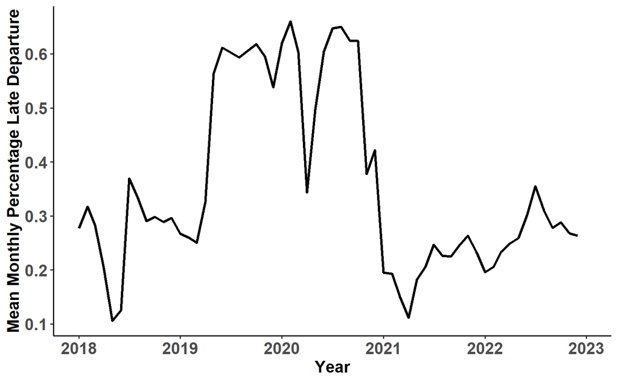

```r
df %>%
  group_by(date) %>%
  summarise(mean_monthly_pct_late_departure = mean(pct_late_departure, na.rm = TRUE)) %>%
  ggplot(aes(date, mean_monthly_pct_late_departure, size = 1)) +
  theme_classic() +
  geom_line(size = 1) +
  scale_x_date(date_breaks = "1 year", date_labels = "%Y", limits = as.Date(c("2018-01-01", "2022-12-31"))) +
  xlab("Year") +
  ylab("Mean Monthly Percentage Late Departure") +
  theme(axis.text = element_text(size = 14, face = "bold"),
        axis.title = element_text(size = 14, face = "bold"),
        legend.text = element_text(size = 14, face = "bold"),
        legend.title = element_text(size = 14, face = "bold"))
```

Let’s compare cancellations and delays

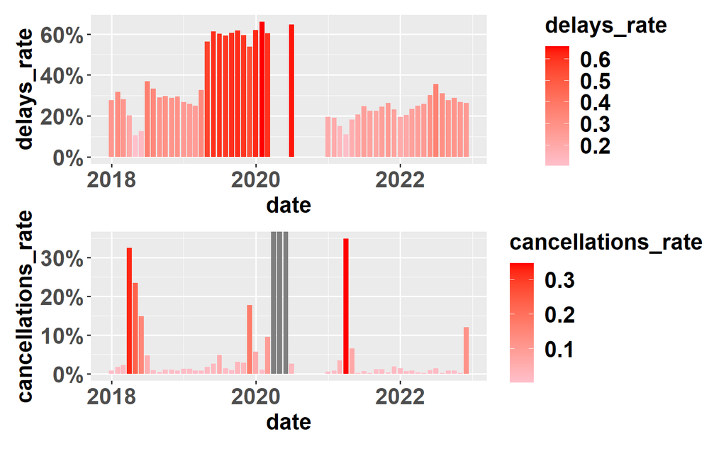

```r
p3 = df %>%
  group_by(year,date) %>%
  summarise(delays_rate = mean(pct_late_departure)) %>%
  ungroup() %>%
  ggplot(aes(date,delays_rate,fill=delays_rate))+
  scale_fill_gradient(low="pink", high="red")+
  scale_y_continuous(labels = percent_format())+
  geom_bar(stat = "identity")+
theme(axis.text=element_text(size=16,face="bold"),
        axis.title=element_text(size=16,face="bold"),
        legend.text =element_text(size=16,face="bold"),
        legend.title = element_text(size=16,face="bold"))
p4 = df %>%
  group_by(year,date) %>%
  summarise(cancellations_rate = mean(mean_monthly_pct_cancelled)) %>%
  ggplot(aes(date,cancellations_rate,fill=cancellations_rate))+
  scale_fill_gradient(low="pink", high="red")+
  scale_y_continuous(labels = percent_format())+
  geom_bar(stat = "identity")+
theme(axis.text=element_text(size=16,face="bold"),
        axis.title=element_text(size=16,face="bold"),
        legend.text =element_text(size=16,face="bold"),
        legend.title = element_text(size=16,face="bold"))
p3/p4
```

Check if busy stations with more trains tend to have delays more than less busy stations.

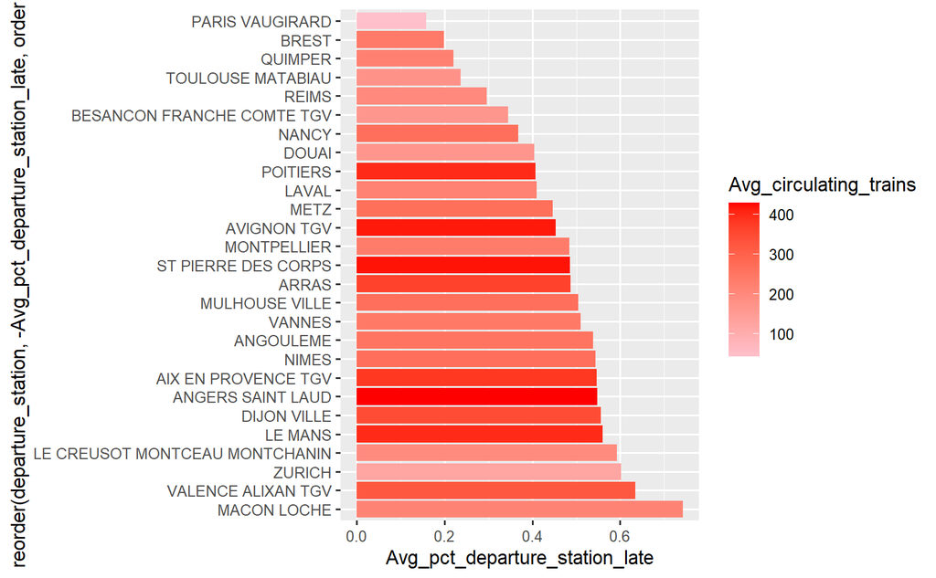

```r
df %>%
  group_by(departure_station) %>%
  summarise(Avg_pct_departure_station_late = mean(pct_late_departure),
            Avg_circulating_trains = mean(total_num_trips)) %>%
  arrange(desc(Avg_pct_departure_station_late)) %>%
  filter(Avg_pct_departure_station_late>0.1) %>%
  ggplot(aes(x = reorder(departure_station, -Avg_pct_departure_station_late,order = F), y= Avg_pct_departure_station_late,fill= Avg_circulating_trains))+
  scale_fill_gradient(low='pink', high='red')+
  geom_bar(stat = "identity")+
  coord_flip()
```

How do the causes of delay fluctuate over time?

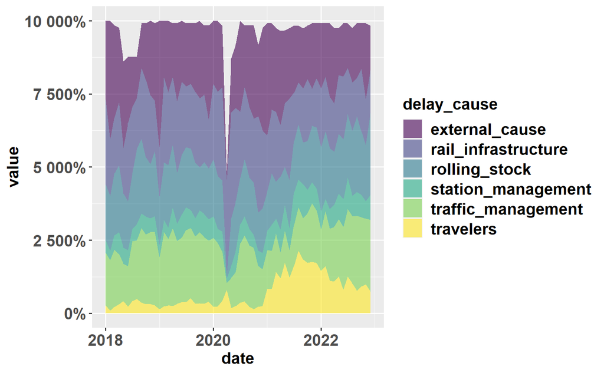

```r
df %>%
  group_by(year,month) %>%
        summarise(across(starts_with("delay_"), mean,na.rm = T)) %>%
         mutate(date = as.Date(sprintf("%d-%02d-01",year,month))) %>%
        pivot_longer(cols = starts_with("delay"),names_to = "delay") %>%
        mutate(delay = substring(delay,nchar("delay_cause_")+1)) %>%
        rename(delay_cause = delay) %>%
  ggplot(aes(date,value,fill = delay_cause))+
  scale_fill_viridis(discrete = T)+
  geom_area(alpha = 0.6)+
  scale_y_continuous(labels = percent_format())+
theme(axis.text=element_text(size=14,face="bold"),
        axis.title=element_text(size=14,face="bold"),
        legend.text =element_text(size=14,face="bold"),
        legend.title = element_text(size=14,face="bold"))
```

Group by service

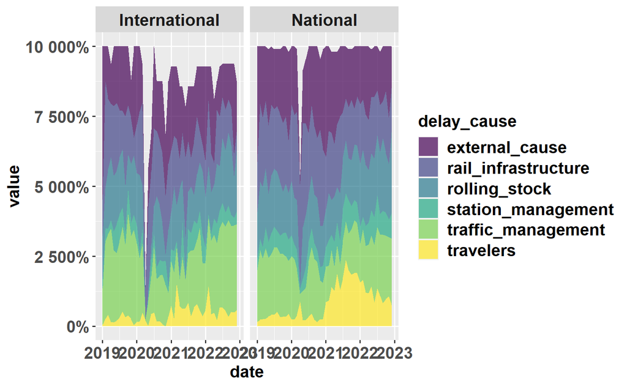

```r
df %>%
  filter(year != 2018) %>%
  group_by(year,month,service) %>%
        summarise(across(starts_with("delay_"), mean,na.rm = T)) %>%
         mutate(date = as.Date(sprintf("%d-%02d-01",year,month))) %>%
        pivot_longer(cols = starts_with("delay"),names_to = "delay") %>%
        mutate(delay = substring(delay,nchar("delay_cause_")+1)) %>%
        rename(delay_cause = delay) %>%
  ggplot(aes(date,value,fill = delay_cause))+
  scale_fill_viridis(discrete = T)+
  facet_grid(~service) +
  geom_area(alpha = 0.7)+
  scale_y_continuous(labels = percent_format())+
theme(axis.text=element_text(size=14,face="bold"),
        axis.title=element_text(size=14,face="bold"),
        legend.text =element_text(size=14,face="bold"),
        legend.title = element_text(size=14,face="bold"),
     strip.text = element_text(face="bold", size=14))
```